# CS236781: Deep Learning on Computational Accelerators

# Homework Assignment 4

Faculty of Computer Science, Technion.

Submitted by:

| # | Name | Id | email |
| --- | --- | --- | --- |
| Student 1 | Alexander Shender | 328626114 | sakasova@campus.technion.ac.il |
| Student 2 | Omer Gottlieb | 302184064 | omergottlieb@campus.technion.ac.il |

## Introduction

In this assignment we'll explore deep reinforcement learning. We'll implement two popular and related methods for directly learning the policy of an agent for playing a simple video game.

## General Guidelines

- Please read the [getting started page](https://vistalab-technion.github.io/cs236781/assignments/getting-started) on the course website. It explains how to **setup, run and submit** the assignment.
- This assignment requires running on GPU-enabled hardware. Please read the [course servers usage guide](https://vistalab-technion.github.io/cs236781/assignments/hpc-servers). It explains how to use and run your code on the course servers to benefit from training with GPUs.
- The text and code cells in these notebooks are intended to guide you through the assignment and help you verify your solutions. The notebooks **do not need to be edited** at all (unless explicitly specified). The only exception is to fill your name(s) in the above cell before submission. Please do not remove sections or change the order of any cells.
- All your code (and even answers to questions) should be written in the files within the python package corresponding the assignment number (`hw1`, `hw2`, etc). You can of course use any editor or IDE to work on these files.

## Contents

- Part1: Deep Reinforcement Learning
  - Policy Gradients
  - Advantage Actor-Critic (AAC)
  - Questions
- Part2: Summary Questions
- Part3: Mini-Project

$$ \newcommand{\mat}[1]{\boldsymbol {#1}} \newcommand{\mattr}[1]{\boldsymbol {#1}^\top} \newcommand{\matinv}[1]{\boldsymbol {#1}^{-1}} \newcommand{\vec}[1]{\boldsymbol {#1}} \newcommand{\vectr}[1]{\boldsymbol {#1}^\top} \newcommand{\rvar}[1]{\mathrm {#1}} \newcommand{\rvec}[1]{\boldsymbol{\mathrm{#1}}} \newcommand{\diag}{\mathop{\mathrm {diag}}} \newcommand{\set}[1]{\mathbb {#1}} \newcommand{\cset}[1]{\mathcal{#1}} \newcommand{\norm}[1]{\left\lVert#1\right\rVert} \newcommand{\pderiv}[2]{\frac{\partial #1}{\partial #2}} \newcommand{\bb}[1]{\boldsymbol{#1}} \newcommand{\E}[2][]{\mathbb{E}_{#1}\left[#2\right]} \newcommand{\ip}[3]{\left<#1,#2\right>_{#3}} \newcommand{\given}[]{\,\middle\vert\,} \newcommand{\DKL}[2]{\cset{D}_{\text{KL}}\left(#1\,\Vert\, #2\right)} \newcommand{\grad}[]{\nabla} $$

# Part 1: Deep Reinforcement Learning

In the tutorial we have seen value-based reinforcement learning, in which we learn to approximate the action-value function $q(s,a)$.

In this exercise we'll explore a different approach, directly learning the agent's policy distribution, $\pi(a|s)$ by using *policy gradients*, in order to safely land on the moon!

```python
%load_ext autoreload
%autoreload 2
%matplotlib inline

import unittest
import os
import sys
import pathlib
import urllib
import shutil
import re

import numpy as np
import torch
import torch.nn as nn
import torch.optim as optim
import matplotlib.pyplot as plt
```

```python
test = unittest.TestCase()
plt.rcParams.update({'font.size': 12})
device = torch.device('cuda' if torch.cuda.is_available() else 'cpu')

# Prefer CPU, GPU won't help much in this assignment
device = 'cpu'
print('Using device:', device)

# Seed for deterministic tests
SEED = 42
```

```
Using device: cpu
```

Some technical notes before we begin:

- This part does not require a GPU. We won't need large models, and the computation bottleneck will be the generation of episodes to train on.
- In order to run this notebook on the server, you must prepend the `xvfb-run` command to create a virtual screen. For example,
  - to run this notebook with `srun` do

    ```
      srun -c2 --gres=gpu:1 xvfb-run -a -s "-screen 0 1440x900x24" python main.py run-nb <filename>
    ```

  - To run the submission script, do

    ```
      srun -c2 xvfb-run -a -s "-screen 0 1440x900x24" python main.py prepare-submission ...
    ```

  - note that we have already included the `xvfb-run` command inside the `jupyter-lab.sh` script, so you can use it as usual with `srun`. and so on.
- The OpenAI `gym` library is not officially supported on windows. However it should be possible to install and run the necessary environment for this exercise. However, we cannot provide you with technical support for this. If you have trouble installing locally, we suggest running on the course server.

## Policy gradients

Recall from the tutorial that we define the **policy** of an agent as the conditional distribution, $$ \pi(a|s) = \Pr(a_t=a\vert s_t=s), $$ which defines how likely the agent is to take action $a$ at state $s$.

Furthermore we define the action-value function, $$ q_{\pi}(s,a) = \E{g_t(\tau)|s_t = s,a_t=a,\pi} $$ where $$ g_t(\tau) = r_{t+1}+\gamma r_{t+2} + \dots = \sum_{k=0}^{\infty} \gamma^k r_{t+1+k}, $$ is the total discounted reward of a specific trajectory $\tau$ from time $t$, and the expectation in $q$ is over all possible trajectories, $ \tau=\left\{ (s_0,a_0,r_1,s_1), \dots (s_T,a_T,r_{T+1},s_{T+1}) \right\}. $

In the tutorial we saw that we can learn a value function starting with some random function and updating it iteratively by using the **Bellman optimality equation**. Given that we have some action-value function, we can immediately create a policy based on that by simply selecting an action which maximize the action-value at the current state, i.e. $$ \pi(a|s) = \begin{cases} 1, & a = \arg\max_{a'\in\cset{A}} q(s,a') \\ 0, & \text{else} \end{cases}. $$ This is called $q$-learning. This approach aims to obtain a policy indirectly through the action-value function. Yet, in most cases we don't actually care about knowing the value of particular states, since all we need is a good policy for our agent.

Here we'll take a different approach and learn a policy distribution $\pi(a|s)$ directly - by using **policy gradients**.

### Formalism

We define a parametric policy, $\pi_\vec{\theta}(a|s)$, and maximize total discounted reward (or minimize the negative reward): $$ \mathcal{L}(\vec{\theta})=\E[\tau]{-g(\tau)|\pi_\vec{\theta}} = -\int g(\tau)p(\tau|\vec{\theta})d\tau, $$ where $p(\tau|\vec{\theta})$ is the probability of a specific trajectory $\tau$ under the policy defined by $\vec{\theta}$.

Since we want to find the parameters $\vec{\theta}$ which minimize $\mathcal{L}(\vec{\theta})$, we'll compute the gradient w.r.t. $\vec{\theta}$: $$ \grad\mathcal{L}(\vec{\theta}) = -\int g(\tau)\grad p(\tau|\vec{\theta})d\tau. $$

Unfortunately, if we try to write $p(\tau|\vec{\theta})$ explicitly, we find that computing it's gradient with respect to $\vec{\theta}$ is quite intractable due to a huge product of terms depending on $\vec{\theta}$: $$ p(\tau|\vec{\theta})=p\left(\left\{ (s_t,a_t,r_{t+1},s_{t+1})\right\}_{t\geq0}\given\vec{\theta}\right) =p(s_0)\prod_{t\geq0} \pi_{\vec{\theta}}(a_t|s_t)p(s_{t+1}|s_t,a_t). $$

However, by using the fact that $\grad_{x}\log(f(x))=\frac{\grad_{x}f(x)}{f(x)}$, we can convert the product into a sum: $$ \begin{align} \grad\mathcal{L}(\vec{\theta}) &= -\int g(\tau)\grad p(\tau|\vec{\theta})d\tau = -\int g(\tau)\frac{\grad p(\tau|\vec{\theta})}{p(\tau|\vec{\theta})}p(\tau|\vec{\theta})d\tau \\ &= -\int g(\tau)\grad\log\left(p(\tau|\vec{\theta})\right)p(\tau|\vec{\theta})d\tau \\ &= -\int g(\tau)\grad\log\left( p(s_0)\prod_{t\geq0} \pi_{\vec{\theta}}(a_t|s_t)p(s_{t+1}|s_t,a_t) \right) p(\tau|\vec{\theta})d\tau \\ &= -\int g(\tau)\grad\left( \log p(s_0) + \sum_{t\geq0} \log \pi_{\vec{\theta}}(a_t|s_t) + \sum_{t\geq0}\log p(s_{t+1}|s_t,a_t) \right) p(\tau|\vec{\theta})d\tau \\ &= -\int g(\tau)\sum_{t\geq0} \grad\log \pi_{\vec{\theta}}(a_t|s_t) p(\tau|\vec{\theta})d\tau \\ &= \E[\tau]{-g(\tau)\sum_{t\geq0} \grad\log \pi_{\vec{\theta}}(a_t|s_t)}. \end{align} $$

This is the "vanilla" version of the policy gradient. We can interpret is as a weighted log-likelihood function. The log-policy is the log-likelihood term we wish to maximize and the total discounted reward acts as a weight: high-return positive trajectories will cause the probability of actions taken during them to increase, and negative-return trajectories will cause the probabilities of actions taken to decrease.

The major drawback of the policy-gradient is it's high variance, which causes erratic optimization behavior and therefore slow convergence. One reason for this is that the log-policy weight term, $g(\tau)$ can vary wildly between different trajectories, even if they're similar in actions. Later on we'll implement the loss and explore some methods of variance reduction.

### Landing on the moon with policy gradients

In the spirit of the recent achievements of the Israeli space industry, we'll apply our reinforcement learning skills to solve a simple game called **LunarLander**.

This game is available as an `environment` in OpenAI `gym`.

[video not shown]

In this environment, you need to control the lander and get it to land safely on the moon. To do so, you must apply bottom, right or left thrusters (each are either fully on or fully off) and get it to land within the designated zone as quickly as possible and with minimal wasted fuel.

```python
import gym

# Just for fun :) ... but also to re-define the default max number of steps
ENV_NAME = 'Beresheet-v2'
MAX_EPISODE_STEPS = 300
if ENV_NAME not in gym.envs.registry.env_specs:
    gym.register(
        id=ENV_NAME,
        entry_point='gym.envs.box2d:LunarLander',
        max_episode_steps=MAX_EPISODE_STEPS,
        reward_threshold=200,
    )
```

```python
import gym

env = gym.make(ENV_NAME)

print(env)
print(f'observations space: {env.observation_space}')
print(f'action space: {env.action_space}')

ENV_N_ACTIONS = env.action_space.n
ENV_N_OBSERVATIONS = env.observation_space.shape[0]
```

```
<TimeLimit<LunarLander<Beresheet-v2>>>
observations space: Box(-inf, inf, (8,), float32)
action space: Discrete(4)
```

The observations at each step is the Lander's position, velocity, angle, angular velocity and ground contact state. The actions are no-op, fire left truster, bottom thruster and right thruster.

You are **highly encouraged** to read the [documentation](https://github.com/openai/gym/blob/master/gym/envs/box2d/lunar_lander.py) in the source code of the `LunarLander` environment to understand the reward system, and see how the actions and observations are created.

```python
s = env.reset()  # returns initial state
new_action = env.action_space.sample()  # sample action

s, r, done, info = env.step(new_action) # perform action

#       s (list): The state. Attributes:
#                 s[0] is the horizontal coordinate
#                 s[1] is the vertical coordinate
#                 s[2] is the horizontal speed
#                 s[3] is the vertical speed
#                 s[4] is the angle
#                 s[5] is the angular speed
#                 s[6] 1 if first leg has contact, else 0
#                 s[7] 1 if second leg has contact, else 0

r
```

```
1.5674098561993333
```

### Policy network and Agent

Let's start with our policy-model. This will be a simple neural net, which should take an observation and return a score for each possible action.

**TODO**:

1. Implement all methods in the `PolicyNet` class in the `hw4/rl_pg.py` module. Start small. A simple MLP with a few hidden layers is a good starting point. You can come back and change it later based on the the experiments.  
   Notice that we'll use the `build_for_env` method to instantiate a `PolicyNet` based on the configuration of a given environment.
2. If you need hyperparameters to configure your model (e.g. number of hidden layers, sizes, etc.), add them in `part1_pg_hyperparams()` in `hw4/answers.py`.

```python
import hw4.rl_pg as hw4pg
import hw4.answers

hp = hw4.answers.part1_pg_hyperparams()

# You can add keyword-args to this function which will be populated from the
# hyperparameters dict.
p_net = hw4pg.PolicyNet.build_for_env(env, device, **hp)
p_net
```

```
PolicyNet(
  (net): Sequential(
    (0): Linear(in_features=8, out_features=100, bias=True)
    (1): ReLU()
    (2): Linear(in_features=100, out_features=100, bias=True)
    (3): ReLU()
    (4): Linear(in_features=100, out_features=100, bias=True)
    (5): ReLU()
    (6): Linear(in_features=100, out_features=4, bias=True)
  )
)
```

```python
env_input = torch.tensor(s)

# print(env_input.shape)
# env_input = torch.unsqueeze(env_input, 0)
# print(env_input.shape)

actions_score = p_net(env_input)
print(actions_score)

curr_state = torch.tensor(env.reset(), device='cpu', dtype=torch.float)
```

```
tensor([-0.0793,  0.0372,  0.1129, -0.0557], grad_fn=<AddBackward0>)
```

Now we need an **agent**. The purpose of our agent will be to act according to the current policy and generate experiences. Our `PolicyAgent` will use a `PolicyNet` as the current policy function.

We'll also define some extra datatypes to help us represent the data generated by our agent. You can find the `Experience`, `Episode` and `TrainBatch` datatypes in the `hw4/rl_data.py` module.

**TODO**: Implement the `current_action_distribution()` method of the `PolicyAgent` class in the `hw4/rl_pg.py` module.

```python
for i in range (10):
    agent = hw4pg.PolicyAgent(env, p_net, device)
    d = agent.current_action_distribution()

    test.assertSequenceEqual(d.shape, (env.action_space.n,))
    test.assertAlmostEqual(d.sum(), 1.0, delta=1e-5)

print(d)
```

```
tensor([0.2277, 0.2600, 0.2778, 0.2345], grad_fn=<SoftmaxBackward>)
```

**TODO**: Implement the `step()` method of the `PolicyAgent`.

```python
agent = hw4pg.PolicyAgent(env, p_net, device)
exp = agent.step()

test.assertIsInstance(exp, hw4pg.Experience)
print(exp)
```

```
Experience(state=tensor([-0.0066,  1.4132, -0.6649,  0.1029,  0.0076,  0.1506,  0.0000,  0.0000]), action=0, reward=-0.488636965398598, is_done=False)
```

To test our agent, we'll write some code that allows it to play an environment. We'll use the `Monitor` wrapper in `gym` to generate a video of the episode for visual debugging.

**TODO**: Complete the implementation of the `monitor_episode()` method of the `PolicyAgent`.

```python
env, n_steps, reward = agent.monitor_episode(ENV_NAME, p_net, device=device)
```

To display the Monitor video in this notebook, we'll use a helper function from our `jupyter_utils` and a small wrapper that extracts the path of the last video file.

```python
import cs236781.jupyter_utils as jupyter_utils

def show_monitor_video(monitor_env, idx=0, **kw):
    # Extract video path
    video_path = monitor_env.videos[idx][0]
    video_path = os.path.relpath(video_path, start=os.path.curdir)

    # Use helper function to embed the video
    return jupyter_utils.show_video_in_notebook(video_path, **kw)
```

```python
print(f'Episode ran for {n_steps} steps. Total reward: {reward:.2f}')

show_monitor_video(env)
```

```
Episode ran for 81 steps. Total reward: -69.11
```

[video not shown]

### Training data

The next step is to create data to train on. We need to train on batches of state-action pairs, so that our network can learn to predict the actions.

We'll split this task into three parts:

1. Generate a batch of `Episode`s, by using an `Agent` that's playing according to our current policy network. Each `Episode` object contains the `Experience` objects created by the agent.
2. Calculate the total discounted reward for each state we encountered and action we took. This is our action-value estimate.
3. Convert the `Episode`s into a batch of tensors to train on. Each batch will contain states, action taken per state, reward accrued, and the calculated estimated state-values. These will be stored in a `TrainBatch` object.

**TODO**: Complete the implementation of the `episode_batch_generator()` method in the `TrainBatchDataset` class within the `hw4.rl_data` module. This will address part 1 in the list above.

```python
import hw4.rl_data as hw4data

def agent_fn():
    env = gym.make(ENV_NAME)
    hp = hw4.answers.part1_pg_hyperparams()
    p_net = hw4pg.PolicyNet.build_for_env(env, device, **hp)
    return hw4pg.PolicyAgent(env, p_net, device)

ds = hw4data.TrainBatchDataset(agent_fn, episode_batch_size=8, gamma=0.9)
batch_gen = ds.episode_batch_generator()
b = next(batch_gen)
print('First episode:', b[0])

test.assertEqual(len(b), 8)
for ep in b:
    test.assertIsInstance(ep, hw4data.Episode)

    # Check that it's a full episode
    is_done = [exp.is_done for exp in ep.experiences]
    test.assertFalse(any(is_done[0:-1]))
    test.assertTrue(is_done[-1])
```

```
First episode: Episode(total_reward=-220.48, #experences=106)
```

```python
b
```

```
(Episode(total_reward=-220.48, #experences=106),
 Episode(total_reward=-100.62, #experences=123),
 Episode(total_reward=-224.34, #experences=103),
 Episode(total_reward=-178.65, #experences=81),
 Episode(total_reward=-471.07, #experences=112),
 Episode(total_reward=-141.07, #experences=113),
 Episode(total_reward=-344.94, #experences=126),
 Episode(total_reward=-224.56, #experences=88))
```

**TODO**: Complete the implementation of the `calc_qvals()` method in the `Episode` class. This will address part 2. These q-values are an estimate of the actual action value function: $$\hat{q}_{t} = \sum_{t'\geq t} \gamma^{t'-t}r_{t'+1}.$$

```python
np.random.seed(SEED)
test_rewards = np.random.randint(-10, 10, 100)
test_experiences = [hw4pg.Experience(None,None,r,False) for r in test_rewards]
test_episode = hw4data.Episode(np.sum(test_rewards), test_experiences)

qvals = test_episode.calc_qvals(0.9)
qvals = list(qvals)

expected_qvals = np.load(os.path.join('tests', 'assets', 'part1_expected_qvals.npy'))
for i in range(len(test_rewards)):
    test.assertAlmostEqual(expected_qvals[i], qvals[i], delta=1e-3)
```

**TODO**: Complete the implementation of the `from_episodes()` method in the `TrainBatch` class. This will address part 3.

Notes:

- The `TrainBatchDataset` class provides a generator function that will use the above function to lazily generate batches of training samples and labels on demand.
- This allows us to use a standard `PyTorch` dataloader to wrap our Dataset and provide us with parallel data loading for free! This means we can run multiple environments with multiple agents in separate background processes to generate data for training and thus prevent the data loading bottleneck which is caused by the fact that we must generate full Episodes to train on in order to calculate the q-values.
- We'll set the `DataLoader`'s `batch_size` to `None` because we have already implemented custom batching in our dataset.
- You can choose the number of worker processes generating data using the `num_workers` parameter in the hyperparams dict. Set `num_workers=0` to disable parallelization.

```python
from torch.utils.data import DataLoader

hp = hw4.answers.part1_pg_hyperparams()

ds = hw4data.TrainBatchDataset(agent_fn, episode_batch_size=8, gamma=0.9)
dl = DataLoader(
    ds,
    batch_size=None,
    num_workers=hp['num_workers'],
    multiprocessing_context='fork' if hp['num_workers'] > 0 else None
)


for i, train_batch in enumerate(dl):
    states, actions, qvals, reward_mean = train_batch
    print(f'#{i}: {train_batch}')
    test.assertEqual(states.shape[0], actions.shape[0])
    test.assertEqual(qvals.shape[0], actions.shape[0])
    test.assertEqual(states.shape[1], env.observation_space.shape[0])
    if i > 5:
        break
```

```
#0: TrainBatch(states: torch.Size([681, 8]), actions: torch.Size([681]), q_vals: torch.Size([681])), num_episodes: 8)
#1: TrainBatch(states: torch.Size([666, 8]), actions: torch.Size([666]), q_vals: torch.Size([666])), num_episodes: 8)
#2: TrainBatch(states: torch.Size([709, 8]), actions: torch.Size([709]), q_vals: torch.Size([709])), num_episodes: 8)
#3: TrainBatch(states: torch.Size([768, 8]), actions: torch.Size([768]), q_vals: torch.Size([768])), num_episodes: 8)
#4: TrainBatch(states: torch.Size([711, 8]), actions: torch.Size([711]), q_vals: torch.Size([711])), num_episodes: 8)
#5: TrainBatch(states: torch.Size([749, 8]), actions: torch.Size([749]), q_vals: torch.Size([749])), num_episodes: 8)
#6: TrainBatch(states: torch.Size([635, 8]), actions: torch.Size([635]), q_vals: torch.Size([635])), num_episodes: 8)
```

### Loss functions

As usual, we need a loss function to optimize over. We'll calculate three types of losses:

1. The causal vanilla policy gradient loss.
2. The policy gradient loss, with a baseline to reduce variance.
3. An entropy-based loss whos purpose is to diversify the agent's action selection, and prevent it from being "too sure" about its actions. This loss will be used together with one of the above losses.

#### Causal vanilla policy-gradient

We have derived the policy-gradient as $$ \grad\mathcal{L}(\vec{\theta}) = \E[\tau]{-g(\tau)\sum_{t\geq0} \grad\log \pi_{\vec{\theta}}(a_t|s_t)}. $$

By writing the discounted reward explicitly and enforcing causality, i.e. the action taken at time $t$ can't affect the reward at time $t'<t$, we can get a slightly lower-variance version of the policy gradient:

$$ \grad\mathcal{L}_{\text{PG}}(\vec{\theta}) = \E[\tau]{-\sum_{t\geq0} \left(\sum_{t'\geq t} \gamma^{t'}r_{t'+1} \right)\grad\log \pi_{\vec{\theta}}(a_t|s_t)}. $$

In practice, the expectation over trajectories is calculated using a Monte-Carlo approach, i.e. simply sampling $N$ trajectories and average the term inside the expectation. Therefore, we will use the following estimated version of the policy gradient:

$$ \begin{align} \hat\grad\mathcal{L}_{\text{PG}}(\vec{\theta}) &=-\frac{1}{N}\sum_{i=1}^{N}\sum_{t\geq0} \left(\sum_{t'\geq t} \gamma^{t'}r_{i,t'+1} \right)\grad\log \pi_{\vec{\theta}}(a_{i,t}|s_{i,t}) \\ &=-\frac{1}{N}\sum_{i=1}^{N}\sum_{t\geq0} \hat{q}_{i,t} \grad\log \pi_{\vec{\theta}}(a_{i,t}|s_{i,t}). \end{align} $$

Note the use of the notation $\hat{q}_{i,t}$ to represent the estimated action-value at time $t$ in the sampled trajectory $i$. Here $\hat{q}_{i,t}$ is acting as the weight-term for the policy gradient.

**TODO**: Complete the implementation of the `VanillaPolicyGradientLoss` class in the `hw4/rl_pg.py` module.

```python
# Ensure deterministic run
env = gym.make(ENV_NAME)
env.seed(SEED)
torch.manual_seed(SEED)

def agent_fn():
    # Use a simple "network" here, so that this test doesn't depend on
    # your specific PolicyNet implementation
    p_net_test = nn.Linear(ENV_N_OBSERVATIONS, ENV_N_ACTIONS, bias=True)
    agent = hw4pg.PolicyAgent(env, p_net_test)
    return agent

dataloader = hw4data.TrainBatchDataset(agent_fn, gamma=0.9, episode_batch_size=4)

test_batch = next(iter(dataloader))

# print((test_batch.q_vals[1:10]))
# print((test_batch.actions[0:10]))

test_action_scores = torch.randn(len(test_batch), env.action_space.n)
print(f"{test_batch=}", end='\n\n')
print(f"test_action_scores=\n{test_action_scores}\nshape={test_action_scores.shape}", end='\n\n')

loss_fn_p = hw4pg.VanillaPolicyGradientLoss()
loss_p, _ = loss_fn_p(test_batch, test_action_scores)

print(f'{loss_p=}')
test.assertAlmostEqual(loss_p.item(), -36.642, delta=1e-2)
```

```
test_batch=TrainBatch(states: torch.Size([388, 8]), actions: torch.Size([388]), q_vals: torch.Size([388])), num_episodes: 4)

test_action_scores=
tensor([[-7.8158e-01, -1.5094e-01,  4.1993e-01,  1.4059e+00],
        [ 1.3185e+00,  2.8492e-05,  1.4242e+00, -6.2004e-01],
        [ 1.1881e+00,  2.0556e+00,  6.6027e-01, -1.1078e+00],
        ...,
        [-3.4807e-01, -9.6609e-01, -6.5453e-01, -2.0421e+00],
        [-1.1453e+00,  8.8890e-01,  2.4767e-01,  9.7610e-01],
        [-1.2878e+00,  1.9194e+00, -9.3162e-01, -3.8786e-01]])
shape=torch.Size([388, 4])

loss_p=tensor(-36.6423)
```

#### Policy-gradient with baseline

Another way to reduce the variance of our gradient is to use relative weighting of the log-policy instead of absolute reward values. $$ \hat\grad\mathcal{L}_{\text{BPG}}(\vec{\theta}) =-\frac{1}{N}\sum_{i=1}^{N}\sum_{t\geq0} \left(\hat{q}_{i,t}-b\right) \grad\log \pi_{\vec{\theta}}(a_{i,t}|s_{i,t}). $$ In other words, we don't measure a trajectory's worth by it's total reward, but by how much better that total reward is relative to some expected ("baseline") reward value, denoted above by $b$. Note that subtracting a baseline has no effect on the expected value of the policy gradient. It's easy to prove this directly by definition.

Here we'll implement a very simple baseline (not optimal in terms of variance reduction): the average of the estimated state-values $\hat{q}_{i,t}$.

**TODO**: Complete the implementation of the `BaselinePolicyGradientLoss` class in the `hw4/rl_pg.py` module.

```python
# Using the same batch and action_scores from above cell
loss_fn_p = hw4pg.BaselinePolicyGradientLoss()
loss_p, loss_dict = loss_fn_p(test_batch, test_action_scores)

print(f'{loss_dict=}')
test.assertAlmostEqual(loss_dict['baseline'], -22.191, delta=1e-2)
test.assertAlmostEqual(loss_p.item(), -0.278, delta=1e-2)
```

```
loss_dict={'loss_p': -0.27867746353149414, 'baseline': -22.191164016723633}
```

#### Entropy loss

The entropy of a probability distribution (in our case the policy), is $$ H(\pi) = -\sum_{a} \pi(a|s)\log\pi(a|s). $$ The entropy is always positive and obtains it's maximum for a uniform distribution. We'll use the entropy of the policy as a bonus, i.e. we'll try to maximize it. The idea is the prevent the policy distribution from becoming too narrow and thus promote the agent's exploration.

First, we'll calculate the maximal possible entropy value of the action distribution for a set number of possible actions. This will be used as a normalization term.

**TODO**: Complete the implementation of the `calc_max_entropy()` method in the `ActionEntropyLoss` class.

```python
loss_fn_e = hw4pg.ActionEntropyLoss(env.action_space.n)
print('max_entropy = ', loss_fn_e.max_entropy)

test.assertAlmostEqual(loss_fn_e.max_entropy, 1.38629436, delta=1e-3)
```

```
max_entropy =  1.3862943611198906
```

**TODO**: Complete the implementation of the `forward()` method in the `ActionEntropyLoss` class.

```python
loss_e, _ = loss_fn_e(test_batch, test_action_scores)
print('loss = ', loss_e)

test.assertAlmostEqual(loss_e.item(), -0.8103, delta=1e-2)
```

```
loss =  tensor(-0.8103)
```

### Training

We'll implement our training procedure as follows:

1. Initialize the current policy to be a random policy.
2. Sample $N$ trajectories from the environment using the current policy.
3. Calculate the estimated $q$-values, $\hat{q}_{i,t} = \sum_{t'\geq t} \gamma^{t'}r_{i,t'+1}$ for each trajectory $i$.
4. Calculate policy gradient estimate $\hat\grad\mathcal{L}(\vec{\theta})$ as defined above.
5. Perform SGD update $\vec{\theta}\leftarrow\vec{\theta}-\eta\hat\grad\mathcal{L}(\vec{\theta})$.
6. Repeat from step 2.

This is known as the **REINFORCE** algorithm.

Fortunately, we've already implemented everything we need for steps 1-4 so we need only a bit more code to put it all together.

The following block implements a wrapper, `train_pg` to create all the objects we need in order to train our policy gradient model.

```python
import hw4.answers
from functools import partial

ENV_NAME = "Beresheet-v2"

def agent_fn_train(agent_type, p_net, seed, envs_dict):
    winfo = torch.utils.data.get_worker_info()
    wid = winfo.id if winfo else 0
    seed = seed + wid if seed else wid

    env = gym.make(ENV_NAME)
    envs_dict[wid] = env
    env.seed(seed)
    np.random.seed(seed)
    torch.manual_seed(seed)

    return agent_type(env, p_net)

def train_rl(agent_type, net_type, loss_fns, hp, seed=None, checkpoints_file=None, **train_kw):
    print(f'hyperparams: {hp}')

    envs = {}
    p_net = net_type(ENV_N_OBSERVATIONS, ENV_N_ACTIONS, **hp)
    p_net.share_memory()
    agent_fn = partial(agent_fn_train, agent_type, p_net, seed, envs)

    dataset = hw4data.TrainBatchDataset(agent_fn, hp['batch_size'], hp['gamma'])
    dataloader = DataLoader(
        dataset, batch_size=None, num_workers=hp['num_workers'],
        multiprocessing_context='fork' if hp['num_workers'] > 0 else None
    )
    optimizer = optim.Adam(p_net.parameters(), lr=hp['learn_rate'], eps=hp['eps'])

    trainer = hw4pg.PolicyTrainer(p_net, optimizer, loss_fns, dataloader, checkpoints_file)
    try:
        trainer.train(**train_kw)
    except KeyboardInterrupt as e:
        print('Training interrupted by user.')
    finally:
        for env in envs.values():
            env.close()

    # Include final model state
    training_data = trainer.training_data
    training_data['model_state'] = p_net.state_dict()
    return training_data

def train_pg(baseline=False, entropy=False, **train_kwargs):
    hp = hw4.answers.part1_pg_hyperparams()

    loss_fns = []
    if baseline:
        loss_fns.append(hw4pg.BaselinePolicyGradientLoss())
    else:
        loss_fns.append(hw4pg.VanillaPolicyGradientLoss())
    if entropy:
        loss_fns.append(hw4pg.ActionEntropyLoss(ENV_N_ACTIONS, hp['beta']))

    return train_rl(hw4pg.PolicyAgent, hw4pg.PolicyNet, loss_fns, hp, **train_kwargs)
```

The `PolicyTrainer` class implements the training loop, collects the losses and rewards and provides some useful checkpointing functionality. The training loop will generate batches of episodes and train on them until either:

- The average total reward from the last `running_mean_len` episodes is greater than the `target_reward`, OR
- The number of generated episodes reached `max_episodes`.

Most of this class is already implemented for you.

**TODO**:

1. Complete the training loop by implementing the `train_batch()` method of the `PolicyTrainer`.
2. Tweak the hyperparameters in the `part1_pg_hyperparams()` function within the `hw4/answers.py` module as needed. You get some sane defaults.

Let's check whether our model is actually training. We'll try to reach a very low (bad) target reward, just as a sanity check to see that training works. Your model should be able to reach this target reward within a few batches.

You can increase the target reward and use this block to manually tweak your model and hyperparameters a few times.

```python
target_reward = -140 # VERY LOW target
train_data = train_pg(target_reward=target_reward, seed=SEED, max_episodes=2000, running_mean_len=10)

test.assertGreater(train_data['mean_reward'][-1], target_reward)
```

```
hyperparams: {'batch_size': 32, 'gamma': 0.9, 'beta': 0.05, 'learn_rate': 0.001, 'eps': 1e-08, 'num_workers': 0}
=== Training...
#11: step=00035235, loss_p=-23.63, m_reward(10)=-132.5 (best=-141.2):  19%|█▋       | 384/2000 [00:26<01:49, 14.75it/s]

=== 🚀 SOLVED - Target reward reached! 🚀
```

### Experimenting with different losses

We'll now run a few experiments to see the effect of diferent loss functions on the training dynamics. Namely, we'll try:

1. Vanilla PG (`vpg`): No baseline, no entropy
2. Baseline PG (`bpg`): Baseline, no entropy loss
3. Entropy PG (`epg`): No baseline, with entropy loss
4. Combined PG (`cpg`): Baseline, with entropy loss

```python
from collections import namedtuple
from pprint import pprint
import itertools as it


ExpConfig = namedtuple('ExpConfig', ('name','baseline','entropy'))

def exp_configs():
    exp_names = ('vpg', 'epg', 'bpg', 'cpg')
    z = zip(exp_names, it.product((False, True), (False, True)))
    return (ExpConfig(n, b, e) for (n, (b, e)) in z)

pprint(list(exp_configs()))
```

```
[ExpConfig(name='vpg', baseline=False, entropy=False),
 ExpConfig(name='epg', baseline=False, entropy=True),
 ExpConfig(name='bpg', baseline=True, entropy=False),
 ExpConfig(name='cpg', baseline=True, entropy=True)]
```

We'll save the training data from each experiment for plotting.

```python
import pickle

def dump_training_data(data, filename):
    os.makedirs(os.path.dirname(filename), exist_ok=True)
    with open(filename, mode='wb') as file:
        pickle.dump(data, file)

def load_training_data(filename):
    with open(filename, mode='rb') as file:
        return pickle.load(file)
```

Let's run the experiments! We'll run each configuration for a fixed number of episodes so that we can compare them.

Notes:

1. Until your models start working, you can decrease the number of episodes for each experiment, or only run one experiment.
2. The results will be saved in a file. To re-run the experiments, you can set `force_run` to `True`.

```python
import math

exp_max_episodes = 4000

results = {}
training_data_filename = os.path.join('results', f'part1_exp.dat')

# Set to True to force re-run (careful! will delete old experiment results)
force_run = False

# Skip running if results file exists.
if os.path.isfile(training_data_filename) and not force_run:
    print(f'=== results file {training_data_filename} exists, skipping experiments.')
    results = load_training_data(training_data_filename)

else:
    for n, b, e in exp_configs():
        print(f'=== Experiment {n}')
        results[n] = train_pg(baseline=b, entropy=e, max_episodes=exp_max_episodes, post_batch_fn=None)

    dump_training_data(results, training_data_filename)
```

```
=== results file results\part1_exp.dat exists, skipping experiments.
```

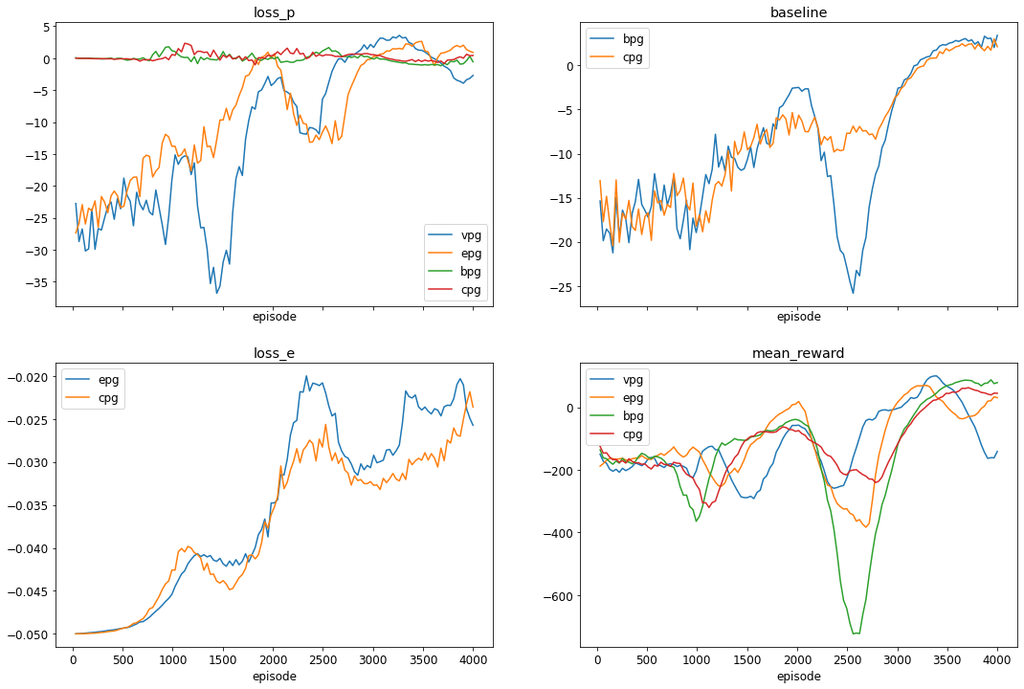

```python
def plot_experiment_results(results, fig=None):
    if fig is None:
        fig, _ = plt.subplots(nrows=2, ncols=2, sharex=True, figsize=(18,12))
    for i, plot_type in enumerate(('loss_p', 'baseline', 'loss_e', 'mean_reward')):
        ax = fig.axes[i]
        for exp_name, exp_res in results.items():
            if plot_type not in exp_res:
                continue
            ax.plot(exp_res['episode_num'], exp_res[plot_type], label=exp_name)
        ax.set_title(plot_type)
        ax.set_xlabel('episode')
        ax.legend()
    return fig

experiments_results_fig = plot_experiment_results(results)
```

You should see positive training dynamics in the graphs (reward going up). If you don't, use them to further update your model or hyperparams.

To pass the test, you'll need to get a best total mean reward of at least 10 in the fixed number of epochs using the combined loss. It's possible to get much higher (over 100).

```python
best_cpg_mean_reward = max(results['cpg']['mean_reward'])
print(f'Best CPG mean reward: {best_cpg_mean_reward:.2f}')

test.assertGreater(best_cpg_mean_reward, 10)
```

```
Best CPG mean reward: 62.82
```

Now let's take a look at a gameplay video of our `cpg` model after the short training!

```python
hp = hw4.answers.part1_pg_hyperparams()
p_net_cpg = hw4pg.PolicyNet.build_for_env(env, **hp)
p_net_cpg.load_state_dict(results['cpg']['model_state'])

env, n_steps, reward = hw4pg.PolicyAgent.monitor_episode(ENV_NAME, p_net_cpg)
print(f'{n_steps} steps, total reward: {reward:.2f}')
show_monitor_video(env)
```

```
300 steps, total reward: 132.65
```

[video not shown]

## Advantage Actor-Critic (AAC)

We have seen that the policy-gradient loss can be interpreted as a log-likelihood of the policy term (selecting a specific action at a specific state), weighted by the future rewards of that choice of action.

However, naïvely weighting by rewards has significant drawbacks in terms of the variance of the resulting gradient. We addressed this by adding a simple baseline term which represented our "expected reward" so that we increase probability of actions leading to trajectories which exceed this expectation and vice-versa.

In this part we'll explore a more powerful baseline, which is the idea behind the AAC method.

### The advantage function

Recall the definition of the state-value function $v_{\pi}(s)$ and action-value function $q_{\pi}(s,a)$:

$$ \begin{align} v_{\pi}(s) &= \E{g(\tau)|s_0 = s,\pi} \\ q_{\pi}(s,a) &= \E{g(\tau)|s_0 = s,a_0=a,\pi}. \end{align} $$

Both these functions represent the value of the state $s$. However, $v_\pi$ averages over the first action according to the policy, while $q_\pi$ fixes the first action and then continues according to the policy.

Their difference is known as the **advantage function**: $$ a_\pi(s,a) = q_\pi(s,a)-v_\pi(s). $$

If $a_\pi(s,a)>0$ it means that it's better (in expectation) to take action $a$ in state $s$ compared to the average action. In other words, $a_\pi(s,a)$ represents the *advantage* of using action $a$ in state $s$ compared to the others.

So far we have used an estimate for $q_\pi$ as our weighting term for the log-policy, with a fixed baseline per batch.

$$ \hat\grad\mathcal{L}_{\text{BPG}}(\vec{\theta}) =-\frac{1}{N}\sum_{i=1}^{N}\sum_{t\geq0} \left(\hat{q}_{i,t}-b\right) \grad\log \pi_{\vec{\theta}}(a_{i,t}|s_{i,t}). $$

Now, we will use the state value as a baseline, so that an estimate of the advantage function is our weighting term:

$$ \hat\grad\mathcal{L}_{\text{AAC}}(\vec{\theta}) =-\frac{1}{N}\sum_{i=1}^{N}\sum_{t\geq0} \left(\hat{q}_{i,t}-v_\pi(s_t)\right) \grad\log \pi_{\vec{\theta}}(a_{i,t}|s_{i,t}). $$

Intuitively, using the advantage function makes sense because it means we're weighting our policy's actions according to how advantageous they are compared to other possible actions.

But how will we know $v_\pi(s)$? We'll learn it of course, using another neural network. This is known as actor-critic learning. We simultaneously learn the policy (actor) and the value of states (critic). We'll treat it as a regression task: given a state $s_t$, our state-value network will output $\hat{v}_\pi(s_t)$, an estimate of the actual unknown state-value. Our regression targets will be the discounted rewards, $\hat{q}_{i,t}$ (see question 2), and we can use a simple MSE as the loss function, $$ \mathcal{L}_{\text{SV}} = \frac{1}{N}\sum_{i=1}^{N}\sum_{t\geq0}\left(\hat{v}_\pi(s_t) - \hat{q}_{i,t}\right)^2. $$

### Implementation

We'll build heavily on our implementation of the regular policy-gradient method, and just add a new model class and a new loss class, with a small modification to the agent.

Let's start with the model. It will accept a state, and return action scores (as before), but also the value of that state. You can experiment with a dual-head network that has a shared base, or implement two separate parts within the network.

**TODO**:

1. Implement the model as the `AACPolicyNet` class in the `hw4/rl_ac.py` module.
2. Set the hyperparameters in the `part1_aac_hyperparams()` function of the `hw4.answers` module.

```python
import hw4.rl_ac as hw4ac

hp = hw4.answers.part1_aac_hyperparams()
pv_net = hw4ac.AACPolicyNet.build_for_env(env, device, **hp)
pv_net
```

```
AACPolicyNet(
  (actions_net): Sequential(
    (0): Linear(in_features=8, out_features=100, bias=True)
    (1): ReLU()
    (2): Linear(in_features=100, out_features=100, bias=True)
    (3): ReLU()
    (4): Linear(in_features=100, out_features=100, bias=True)
    (5): ReLU()
    (6): Linear(in_features=100, out_features=4, bias=True)
  )
  (value_net): Sequential(
    (0): Linear(in_features=8, out_features=100, bias=True)
    (1): ReLU()
    (2): Linear(in_features=100, out_features=100, bias=True)
    (3): ReLU()
    (4): Linear(in_features=100, out_features=100, bias=True)
    (5): ReLU()
    (6): Linear(in_features=100, out_features=1, bias=True)
  )
)
```

**TODO**: Complete the implementation of the agent class, `AACPolicyAgent`, in the `hw4/rl_ac.py` module.

```python
agent = hw4ac.AACPolicyAgent(env, pv_net, device)
exp = agent.step()

test.assertIsInstance(exp, hw4pg.Experience)
print(exp)
```

```
Experience(state=tensor([ 0.0037,  1.4117,  0.3757,  0.0363, -0.0043, -0.0851,  0.0000,  0.0000]), action=3, reward=-1.5333471575559077, is_done=False)
```

**TODO**: Implement the AAC loss function as the class `AACPolicyGradientLoss` in the `hw4/rl_ac.py` module.

```python
loss_fn_aac = hw4ac.AACPolicyGradientLoss(delta=1.)
test_state_values = torch.ones(test_action_scores.shape[0], 1)
loss_t, loss_dict = loss_fn_aac(test_batch, (test_action_scores, test_state_values))

print(f'{loss_dict=}')
test.assertAlmostEqual(loss_dict['adv_m'], -23.191, delta=1e-2)
test.assertAlmostEqual(loss_t.item(), 1183.948, delta=1e-2)
```

```
loss_dict={'loss_p': -38.28092956542969, 'loss_v': 1222.2301025390625, 'adv_m': -23.191162109375}
```

### Experimentation

Let's run the same experiment as before, but with the AAC method and compare the results.

```python
def train_aac(baseline=False, entropy=False, **train_kwargs):
    hp = hw4.answers.part1_aac_hyperparams()
    loss_fns = [hw4ac.AACPolicyGradientLoss(hp['delta']), hw4pg.ActionEntropyLoss(ENV_N_ACTIONS, hp['beta'])]
    return train_rl(hw4ac.AACPolicyAgent, hw4ac.AACPolicyNet, loss_fns, hp, **train_kwargs)
```

```python
training_data_filename = os.path.join('results', f'part1_exp_aac.dat')

# Set to True to force re-run (careful, will delete old experiment results)
force_run = False

if os.path.isfile(training_data_filename) and not force_run:
    print(f'=== results file {training_data_filename} exists, skipping experiments.')
    results_aac = load_training_data(training_data_filename)

else:
    print(f'=== Running AAC experiment')
    training_data = train_aac(max_episodes=exp_max_episodes)
    results_aac = dict(aac=training_data)
    dump_training_data(results_aac, training_data_filename)
```

```
=== results file results\part1_exp_aac.dat exists, skipping experiments.
```

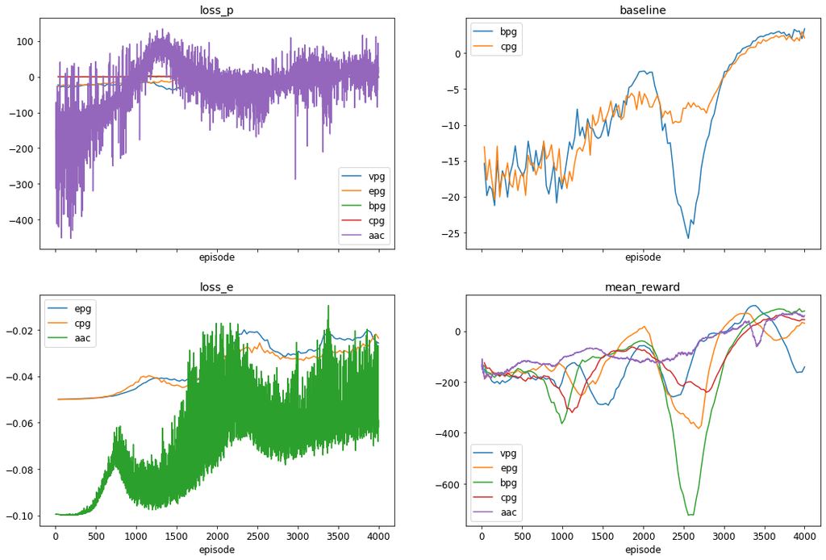

```python
experiments_results_fig = plot_experiment_results(results)
plot_experiment_results(results_aac, fig=experiments_results_fig);
```

You should get better results with the AAC method, so this time the bar is higher (again, you should aim for a mean reward of 100+). Compare the graphs with combined PG method and see if they make sense.

```python
best_aac_mean_reward = max(results_aac['aac']['mean_reward'])
print(f'Best AAC mean reward: {best_aac_mean_reward:.2f}')

test.assertGreater(best_aac_mean_reward, 50)
```

```
Best AAC mean reward: 73.45
```

### Final model training and visualization

Now, using your best model and hyperparams, let's train model for much longer and see the performance. Just for fun, we'll also visualize an episode every now and then so that we can see how well the agent is playing.

**TODO**:

- Run the following block to train.
- Tweak model or hyperparams as necessary.
- Aim for high mean reward, at least 150+. It's possible to get over 200.
- When training is done and you're satisfied with the model's outputs, rename the checkpoint file by adding `_final` to the file name. This will cause the block to skip training and instead load your saved model when running the homework submission script. Note that your submission zip file will not include the checkpoint file. This is OK.

```python
import IPython.display

CHECKPOINTS_FILE = f'checkpoints/{ENV_NAME}-ac.dat'
CHECKPOINTS_FILE_FINAL = f'checkpoints/{ENV_NAME}-ac_final.dat'
TARGET_REWARD = 125
MAX_EPISODES = 15_000

def post_batch_fn(batch_idx, p_net, batch, print_every=200, final=False):
    if not final and batch_idx % print_every != 0:
        return
    env, n_steps, reward = hw4ac.AACPolicyAgent.monitor_episode(ENV_NAME, p_net)
    html = show_monitor_video(env, width="500")
    IPython.display.clear_output(wait=True)
    print(f'Monitor@#{batch_idx}: n_steps={n_steps}, total_reward={reward:.3f}, final={final}')
    IPython.display.display_html(html)


if os.path.isfile(CHECKPOINTS_FILE_FINAL):
    print(f'=== {CHECKPOINTS_FILE_FINAL} exists, skipping training...')
    checkpoint_data = torch.load(CHECKPOINTS_FILE_FINAL)
    hp = hw4.answers.part1_aac_hyperparams()
    pv_net = hw4ac.AACPolicyNet.build_for_env(env, **hp)
    pv_net.load_state_dict(checkpoint_data['params'])
    print(f'=== Running best model...')
    env, n_steps, reward = hw4ac.AACPolicyAgent.monitor_episode(ENV_NAME, pv_net)
    print(f'=== Best model ran for {n_steps} steps. Total reward: {reward:.2f}')
    IPython.display.display_html(show_monitor_video(env))
    best_mean_reward = checkpoint_data["best_mean_reward"]
else:
    print(f'=== Starting training...')
    train_data = train_aac(TARGET_REWARD, max_episodes=MAX_EPISODES,
                           seed=None, checkpoints_file=CHECKPOINTS_FILE, post_batch_fn=post_batch_fn)
    print(f'=== Done, ', end='')
    best_mean_reward = train_data["best_mean_reward"][-1]
    print(f'num_episodes={train_data["episode_num"][-1]}, best_mean_reward={best_mean_reward:.1f}')

test.assertGreaterEqual(best_mean_reward, TARGET_REWARD)
```

```
=== checkpoints/Beresheet-v2-ac_final.dat exists, skipping training...
=== Running best model...
=== Best model ran for 300 steps. Total reward: 160.19
```

[video not shown]

## Questions

**TODO**: Answer the following questions. Write your answers in the appropriate variables in the module `hw4/answers.py`.

```python
from cs236781.answers import display_answer
import hw4.answers
```

### Question 1

Explain qualitatively why subtracting a baseline in the policy-gradient helps reduce it's variance. Specifically, give an example where it helps.

```python
display_answer(hw4.answers.part1_q1)
```

**Your answer:**

As explained in the lecture, the absolute value of the reward is of little meaning in the decision whether to increase or decrease the probability of certain action. We need to know whether the certain action increases the expected reward or is the best action to choose in a given state.

Policy weight, by which we multiply the log probabilities, can be huge, if we take the absolute value of the calculated q_values, as in the case with the Vanilla PG. Those are the discounted future rewards. Their value depends on the horizon (depth that we look forward), the reward function structure and variance, and all the future states.

By introducing the baseline, we still detect which actions perform good (better than baseline), but the loss is not so big. We clearly see in the graphs.

in the case with AAC, we subtract the Value function of the state, i.e. the expected return. It includes all the variance of the future states in it. So the $\hat{q}_{i,t}-v_\pi(s_t)$ only depends on the current state, and has lower variance.

### Question 2

In AAC, when using the estimated q-values as regression targets for our state-values, why do we get a valid approximation? Hint: how is $v_\pi(s)$ expressed in terms of $q_\pi(s,a)$?

```python
display_answer(hw4.answers.part1_q2)
```

**Your answer:**

Following the hint, and remembering the definion of Value function and Q-function:

$$ \begin{align} v_{\pi}(s) &= \E{g(\tau)|s_0 = s,\pi} \\ q_{\pi}(s,a) &= \E{g(\tau)|s_0 = s,a_0=a,\pi}. \end{align} $$

The only difference is that the Q-function fixes the first action. Both follow the chosen policy. But in our approximation, the action was already chosen by the policy when this experience was created. So we use this Q-value as target for the Value of the state.

### Question 3

1. Analyze and explain the graphs you got in first experiment run.
2. Compare the experiment graphs you got with the AAC method to the regular PG method (`cpg`).

```python
display_answer(hw4.answers.part1_q3)
```

**Your answer:**

1. In first part graphs we see:

- The loss_p starts at negative for vpg, epg and goes up. This is explainable - the q_vals in the beginning are negative. The log_softmax values are always negative. And the loss_p has minus sign. As q_values in the experiences begin to be less negative, so does the loss_p.

- We can clearly see the effect of the baseline, the losses aren't big, and the variance of the policy network is much smaller

1. The AAC training was much more complex and unstable. Only after precise calibration we were able to train it. Some of the important things we did to calibrate it:

- Adjust the delta, so that the loss of the Critic will be of the same scale as the loss of the policy.

- Adjust the beta, so that the "randomality" of the actions will be controlled.

- Finding the appropriating network for Actor and Critic. In the end it was decided to use separate networks for each, not the 2-head network as proposed.

- adjust the batch size and learning rate. Surprizingly, what worked for us was batch size of 1 and really small learning rate.

By looking at the graphs, we can see that:

- The training is more stable, and can reach higher total return, but requires more tuning.

- On average, we received higher max award.

Difficulties that were met:

1. For big learning rate, and batch size, the loss_p and loss_e values would reach zero at some point. At this point, not further learning was taking place, and those losses would not recover. By looking at the videos we would observe that the agent would do the same actions all over (thus the entropy would be zero). This is seen by as as kind of dead loop which we tried to avoid by adjusting the hyperparameters.

2. After reaching some maximum performance, further training could sometimes deteriorate the performance. So it is important to stop in time

$$ \newcommand{\mat}[1]{\boldsymbol {#1}} \newcommand{\mattr}[1]{\boldsymbol {#1}^\top} \newcommand{\matinv}[1]{\boldsymbol {#1}^{-1}} \newcommand{\vec}[1]{\boldsymbol {#1}} \newcommand{\vectr}[1]{\boldsymbol {#1}^\top} \newcommand{\rvar}[1]{\mathrm {#1}} \newcommand{\rvec}[1]{\boldsymbol{\mathrm{#1}}} \newcommand{\diag}{\mathop{\mathrm {diag}}} \newcommand{\set}[1]{\mathbb {#1}} \newcommand{\cset}[1]{\mathcal{#1}} \newcommand{\norm}[1]{\left\lVert#1\right\rVert} \newcommand{\pderiv}[2]{\frac{\partial #1}{\partial #2}} \newcommand{\bb}[1]{\boldsymbol{#1}} \newcommand{\E}[2][]{\mathbb{E}_{#1}\left[#2\right]} \newcommand{\ip}[3]{\left<#1,#2\right>_{#3}} \newcommand{\given}[]{\,\middle\vert\,} \newcommand{\DKL}[2]{\cset{D}_{\text{KL}}\left(#1\,\Vert\, #2\right)} \newcommand{\grad}[]{\nabla} \newcommand{\norm}[1]{\left\lVert#1\right\rVert} $$

# Part 2: Summary Questions

This section contains summary questions about various topics from the course material.

You can add your answers in new cells below the questions.

**Notes**

- Clearly mark where your answer begins, e.g. write "**Answer:**" in the beginning of your cell.
- Provide a full explanation, even if the question doesn't explicitly state so. We will reduce points for partial explanations!
- This notebook should be runnable from start to end without any errors.

### CNNs

1. Explain the meaning of the term "receptive field" in the context of CNNs.

ANSWER:

The receptive field is the region in the input space, which is observable by some CNN feature. Expliciply - which features in more previous layers do affect some specific feature in later layer.

1. Explain and elaborate about three different ways to control the rate at which the receptive field grows from layer to layer. Compare them to each other in terms of how they combine input features.

ANSWER:

The three ways are:

1. Increase the kernel size of a filter. E.g. from 3X3 to 5X5. This way we directly increase the amount of features that influence 1 feature in the next layer.
2. Increase the stride of the filter. This technique will 'skip' one feature in the filter, thus in the end, bigger amount of features influence the feature that we want to increase its receptive field. This technique is widely used to increase the receptive field dramatically, and not to be focused locally on 1 spot, increasing the spatial extent. Important if we want to focus on large parts of image, and not small.
3. Pooling is a an effective way to increase receptive field. By, for example, making 2x2 pooling (max/avg), each feature combines the information of 4 features from a previous layer, and consequently, combines the information that each of those features had.

In practice, all of those methods are widely used in CNNs.

1. Imagine a CNN with three convolutional layers, defined as follows:

```python
import torch
import torch.nn as nn

cnn = nn.Sequential(
    nn.Conv2d(in_channels=3, out_channels=4, kernel_size=3, padding=1),
    nn.ReLU(),
    nn.MaxPool2d(2),
    nn.Conv2d(in_channels=4, out_channels=16, kernel_size=5, stride=2, padding=2),
    nn.ReLU(),
    nn.MaxPool2d(2),
    nn.Conv2d(in_channels=16, out_channels=32, kernel_size=7, dilation=2, padding=3),
    nn.ReLU(),
)

cnn(torch.rand(size=(1, 3, 1024, 1024), dtype=torch.float32)).shape
```

```
torch.Size([1, 32, 122, 122])
```

What is the size (spatial extent) of the receptive field of each "pixel" in the output tensor?

ANSWER:

Calculating (from end to start):

   After hearing that residual networks can be made much deeper, you decide to change each layer in your network you used the following residual mapping instead $\vec{y}_l=f_l(\vec{x};\vec{\theta}_l)+\vec{x}$, and re-train.

   However, to your surprise, by visualizing the learned filters $\vec{\theta}_l$ you observe that the original network and the residual network produce completely different filters. Explain the reason for this.

ANSWER:

What is missing is of course the non-linear part, e.g. the activation function which is used in the residual block. By simply summing $x$ to the output from the filter, is like adding another filter operation with kernel of size 1x1, and weight of 1. And as we know, applying filters is a linear operation, which can be replaced with 1 filter. So, $\vec{y}_l=f_l(\vec{x};\vec{\theta}_l)+\vec{x}$ would be a wrong thing to do. Instead, we have to introduce an activation function after the convolution layer. Then, sum with $x$ and pass the result to the next activation layer. This is known as a ResNet block (basic one, not bottleneck)

### Dropout

1. Consider the following neural network:

```python
import torch.nn as nn

p1, p2 = 0.1, 0.2
nn.Sequential(
    nn.Conv2d(in_channels=3, out_channels=4, kernel_size=3, padding=1),
    nn.ReLU(),
    nn.Dropout(p=p1),
    nn.Dropout(p=p2),
)
```

```
Sequential(
  (0): Conv2d(3, 4, kernel_size=(3, 3), stride=(1, 1), padding=(1, 1))
  (1): ReLU()
  (2): Dropout(p=0.1, inplace=False)
  (3): Dropout(p=0.2, inplace=False)
)
```

If we want to replace the two consecutive dropout layers with a single one defined as follows:

```
nn.Dropout(p=q)
```

what would the value of `q` need to be? Write an expression for `q` in terms of `p1` and `p2`.

ANSWER:

The parameter 'p' in the Dropout layer is the probability that a certain element will be 'zeroed'. This means, with probability of $1-p$, a neuron will stay.

For first layer, $1-p_1 = 0.9$

For second layer, $1-p_2 = 0.8$

This means the neuron will stay after 2 those layers with probability of $0.9 \cdot 0.8 = 0.72$ Hence, it will dropout with probability of 0.28

So: $q = 0.28$

1. **True or false**: dropout must be placed only after the activation function.

ANSWER: FALSE

This depends on the activation function first of all. If we use ReLU, like we often do, this doesn't matter, since anyway, 0 maps to 0 in ReLU.

1. After applying dropout with a drop-probability of $p$, the activations are scaled by $1/(1-p)$. Prove that this scaling is required in order to maintain the value of each activation unchanged in expectation.

ANSWER:

We do the scaling because in the Test phase, dropout is not applied, and all the neurons are active. So we have to keep the output of each neuron at test time equal to expected output in the training time. Let's denote output of a neuron as $x$ and dropout probability as $p$

Without scaling:

$E(x) = (1-p)\cdot x + p\cdot0 = (1-p)\cdot x$

Scaling by $1/(1-p)$ gives:

$E(x) = ((1-p)\cdot x + p\cdot0)\cdot (1/(1-p)) = ((1-p)\cdot x) \cdot (1/(1-p)) = x$

$E(x) = x$

So we maintain the original value unchanged

### Losses and Activation functions

1. You're training a an image classifier that, given an image, needs to classify it as either a dog (output 0) or a hotdog (output 1). Would you train this model with an L2 loss? if so, why? if not, demonstrate with a numerical example. What would you use instead?

ANSWER:

This is clearly a classification task

Why L2 Loss is a bad choice: The scores given in the question certainly show that those are categorical values.

the output of the network is unbounded. Meaning that giving output of 3, I certainly believe more that this is a hotdog rathat then a dog, but my loss will still be high, and I will correct the neurons for giving 'wrong' result.

What I would do:

For categorical tasks we usually use the Cross Entropy loss function, which maps the output to probabilities of a certain class to be the category. I would use this Cross Entropy Loss, and change the output to give me **2** outputs. Then I will use the Categorical Cross Entropy Loss (Softmax + CE Loss).

1. After months of research into the origins of climate change, you observe the following result:

[figure not shown]

You decide to train a cutting-edge deep neural network regression model, that will predict the global temperature based on the population of pirates in `N` locations around the globe. You define your model as follows:

```python
import torch.nn as nn

N = 42  # number of known global pirate hot spots
H = 128
mlpirate = nn.Sequential(
    nn.Linear(in_features=N, out_features=H),
    nn.Sigmoid(),
    *[
        nn.Linear(in_features=H, out_features=H), nn.Sigmoid(),
    ]*24,
    nn.Linear(in_features=H, out_features=1),
)
```

While training your model you notice that the loss reaches a plateau after only a few iterations. It seems that your model is no longer training. What is the most likely cause?

ANSWER:

We can notice that there are 24 pairs of 'Linear - Sigmoid' blocks used. This will certainly cause the problem of vanishing gradients in the network, because gradients are being multiplied as they progagate into the network during the backpropagation process. In sigmoid function the gradients are close to zero when the absolute value of the input is big. This will cause the deeper layers to get really small updates to their weights, thus not to learn.

1. Referring to question 2 above: A friend suggests that if you replace the `sigmoid` activations with `tanh`, it will solve your problem. Is he correct? Explain why or why not.

ANSWER:

Tanh will **not** solve the problem, since its gradients are also small when the input absolute values are high.

What can solve (mitigate) are for example:

1. ReLU activation
2. ResNet architecture
1. Regarding the ReLU activation, state whether the following sentences are **true or false** and explain:
   1. In a model using exclusively ReLU activations, there can be no vanishing gradients.
   2. The gradient of ReLU is linear with its input when the input is positive.
   3. ReLU can cause "dead" neurons, i.e. activations that remain at a constant value of zero.

ANSWER:

1. FALSE

ReLU doesn't completely solve the vanishing gradient problem (otherwise, the main reason for ResNet block would not exist, we could simply use ReLU). What is being propagated backwards are also the weights of the neurons, and if those are below 1 in absolute value, gradients will vanish anyway.

1. FALSE

The gradient of ReLU is 1 if input is positive and 0 if it's negative.

1. TRUE

This is known as the "Dead RELU" problem. When the neuron is at this state, nothing can take him out, since its output is always 0 from now on, and no gradient will go backwards to fix the weights. The possible fix is using the Leaky ReLU.

### Optimization

1. Explain the difference between: stochastic gradient descent (SGD), mini-batch SGD and regular gradient descent (GD).

ANSWER:

- GD: updating the weights in the gradient direction, and the gradient is calculated by using ALL input data (training set)
- SGD: using single example from the input space to update the gradient. e.g. updating the network after calculating loss for a single sample output compared to true output on that sample.
- minibatch SGD: using minibatches (e.g. of 32, 64, 512) samples to calculate more 'precise' gradient direction. Is most commonly used technique
1. Regarding SGD and GD:
   1. Provide at least two reasons for why SGD is used more often in practice compared to GD.
   2. In what cases can GD not be used at all?

ANSWER:

As I understand, by SGD, the mini-batch SGD is meant. Pure SGD is not used a lot.

A. Why SGD is used more often than GD:

- The input set can be huge, and making a big calculation for a single step is costly.
- SGD calculates an approximation for gradient, and that's ok. The expectation of those gradients is the true gradient, and will lead to a minimum of the loss. We can control with the 'minibatch' size hyperparameter the amount of samples upon which this gradient averaging is made. Using this technique saves time and resources that we need to allocate if we work in parallel architectures.

B. GD will not be used at all if the input training set size is unlimited. For example, the inputs are some synthesized data (environment continous space in RL). We can synthesize any amount of data we want.

1. You have trained a deep resnet to obtain SoTA results on ImageNet. While training using mini-batch SGD with a batch size of $B$, you noticed that your model converged to a loss value of $l_0$ within $n$ iterations (batches across all epochs) on average. Thanks to your amazing results, you secure funding for a new high-powered server with GPUs containing twice the amount of RAM. You're now considering to increase the mini-batch size from $B$ to $2B$. Would you expect the number of of iterations required to converge to $l_0$ to decrease or increase when using the new batch size? explain in detail.

ANSWER:

In short on effect of the batch size:

The larger the batch size, the more accurate is the update to the weights that is calculated, because more examples are taken into account. With fewer examples, the gradient is more dependent on the specific examples that were used.

To answer the question: The batch size has increased 2 times. The gradient updates are now more accurate, so i expect the convergence to the loss value $l_0$ to happpen with **less** than $n$ iterations. It should be noted that big batch sizes can lead to poor generalization.

1. For each of the following statements, state whether they're **true or false** and explain why.
   1. When training a neural network with SGD, every epoch we perform an optimization step for each sample in our dataset.
   2. Gradients obtained with SGD have less variance and lead to quicker convergence compared to GD.
   3. SGD is less likely to get stuck in local minima, compared to GD.
   4. Training with SGD requires more memory than with GD.
   5. Assuming appropriate learning rates, SGD is guaranteed to converge to a local minimum, while GD is guaranteed to converge to the global minimum.
   6. Given a loss surface with a narrow ravine (high curvature in one direction): SGD with momentum will converge more quickly than Newton's method which doesn't have momentum.

ANSWER:

A. **TRUE**

With SGD, each epoch we go over ALL of the samples in the training set, whether one by one or minibatches, and eventually perform optimization on each.

B. **FALSE**

First, gradients with SGD have bigger variance, because they take into calculation less samples. So it will take longer to converge.

C. **TRUE**

Because we take into account each time some other minibatch. For a GD, the gradient for the whole dataset could be 0 at some point, while some minibatch (any permutation of the samples which compose a minibatch) will likely some gradient in this point. Or like in the tutorial 5 said, SGD will get a different loss surfact every iteration

D. **FALSE**

The whole point of using the SGD is to make a training feasible, when the input data sample size is big. Instead of computing the gradient on the error of the prediction of the network for the whole dataset, we compute each time the gradient only for some number (16, 32, etc) of samples.

E. **FALSE**

In general, nothing can guarantee that the GD will converge to the global minimum. This can only be guaranteed when there is only 1 minimum on the 'surface' of the cost function. Imagine that there are 2 minimums, and the current weights position the current loss on the slope of the local minimum. GD will inevitably follow the steepest gradient, which will lead to this local minimum.

F. **TRUE**

Momentum is an addition to the optimizer which accelerates the convergence. It uses the information of the last gradients (moving average) to accelerate the current update in the common direction. In the situation described above (narrow ravine), the momentum will be more useful, since it will accelerate the optimization in the direction along the ravine. While Newton's method will accelerate it more towards the ravine itself, which is not what we want.

1. In tutorial 5 we saw an example of bi-level optimization in the context of deep learning, by embedding an optimization problem as a layer in the network. **True or false**: In order to train such a network, the inner optimization problem must be solved with a descent based method (such as SGD, LBFGS, etc). Provide a mathematical justification for your answer.

ANSWER:

**FALSE**

This is not correct. In order to make a training possible, we need to find a way to transfer further the gradient with respect to the loss. Following the notations from the tutorial, we need to calculate:

$$ \delta \vec{z} = \pderiv{\vec{y}}{\vec{z}} \delta\vec{y} =\mattr{R}\mat{K^{-1}}\delta\vec{y}. $$

If the calculation of the Hessians ${K^{-1}}$ and ${R}$ is feasible, a closed form solution exists, and we can use it to propagate the gradient.

1. You have trained a neural network, where each layer $l$ is represented by the mapping $\vec{y}_l=f_l(\vec{x};\vec{\theta}_l)$ for some arbitrary parametrized functions $f_l(\cdot;\vec{\theta}_l)$. Unfortunately while trying to break the record for the world's deepest network, you discover that you are unable to train your network with more than $L$ layers.
   1. Explain the concepts of "vanishing gradients", and "exploding gradients".
   2. How can each of these problems be caused by increased depth?
   3. Provide a numerical example demonstrating each.
   4. Assuming your problem is either of these, how can you tell which of them it is without looking at the gradient tensor(s)?

ANSWER:

A. I have already explained before, but here it is again:

- Vanishing gradients - gradients are being multiplied as they progagate into the network during the backpropagation process. In sigmoid and tanh function the gradients are close to zero when the absolute value of the input is big. This will cause the deeper layers to get really small updates to their weights, thus not to learn.
- Exploding gradients - are caused by the same idea of 'backpropagating' the gradients back in the network. It is caused by some weights being too large in absolute value, thus causing the $\frac{\delta L}{\delta W}$ ($L$ is loss) to be large, thus propagating backwards big losses, which are multiplied again by values bigger than 1 if the weights are large in the previous layer.

B. If the network is deep, the effect of multiplicating values, which are >> 1 or << 1 for numerous times increases exponentially. If the number of layers is big enough, we inevetably would have either one of 2 cases towards the root of the network.

C. Basic examples. I will supply the ones given in the lecture:

- Vanishing Gradients

  The slope of the activation function will be << 1 consecutively for large amount of layers, e.g. 0.1. Then, let's say, for a network of 10 layers, the $\delta W_1$ would be $0.1^{9}$, which will be further multiplied by the learning rate when updating the weights
- Exploding Gradients In contrast to the Vanishing gradients problem, the exploding gradients are caused rather by the weights in the network, and not the gradient slopes (Sigmoid and tanh max slope value is 1).

D. For vanishing gradients, we can spot that the network eventually stops learning, and will settle on a poor validation error. For exploding gradients, we will see large changes in the loss for each update. (we will see eventually values going to NaN - sign that they are too big in absolute value)

### Backpropagation

1. You wish to train the following 2-layer MLP for a binary classification task: $$ \hat{y} =\mat{W}_2~ \varphi(\mat{W}_1 \vec{x}+ \vec{b}_1) + \vec{b}_2 $$ Your wish to minimize the in-sample loss function is defined as $$ L_{\mathcal{S}} = \frac{1}{N}\sum_{i=1}^{N}\ell(y,\hat{y}) + \frac{\lambda}{2}\left(\norm{\mat{W}_1}_F^2 + \norm{\mat{W}_2}_F^2 \right) $$ Where the pointwise loss is binary cross-entropy: $$ \ell(y, \hat{y}) = - y \log(\hat{y}) - (1-y) \log(1-\hat{y}) $$

   Write an analytic expression for the derivative of the final loss $L_{\mathcal{S}}$ w.r.t. each of the following tensors: $\mat{W}_1$, $\mat{W}_2$, $\mat{b}_1$, $\mat{b}_2$, $\mat{x}$.

ANSWER:

Following the tutorial 3, we rewrite the model:

$$ \hat{y} =\mat{W}_2~ \underbrace{\varphi(\overbrace{\mat{W}_1 \vec{x}+ \vec{b}_1}^{\vec{z}})}_{\vec{a}} + \vec{b}_2, $$

The loss function here is the binary cross-entropy. Calculating the derivative of the loss w.r. to the prediction:

$$\pderiv{\ell}{\vec{\hat y}} = -{\vec y} \cdot \frac{1}{\vec{\hat y}} + (1-\vec{\hat{y}}) \cdot \frac{1}{1-\vec{\hat{y}}} = ... = \frac {\vec{\hat{y}} - {\vec{\hat{y}}}}{\vec{\hat{y}}\cdot(1-\vec{\hat{y}})}$$

Calculating for each of the required variables using the chain rule:

1. For $\mat{W}_2$:

$$ \pderiv{\ell}{\mat{W}_2}= \pderiv{\ell}{\vec{\hat y}}\pderiv{\vec{\hat y}}{\mat{W}_2} =\left( \frac {\vec{\hat{y}} - {\vec{\hat{y}}}}{\vec{\hat{y}}\cdot(1-\vec{\hat{y}})} \right) \vectr{a} $$$$ \nabla_{\mat{W}_2}L_{\mathcal{S}}=\frac{1}{N}\sum_{i=1}^{N} \pderiv{\ell_i}{\mat{W}_2} + \lambda\mat{W}_2 $$

1. For $\mat{W}_1$:

We need to use the chain rule further to calculate its derivatives:

$$ \pderiv{\ell}{\mat{W}_1}= \pderiv{\ell}{\vec{\hat y}}\pderiv{\vec{\hat y}}{\mat{a}}\pderiv{\mat{a}}{\mat{z}}\pderiv{\mat{z}}{\mat{W}_1} = \pderiv{\ell}{\vec{\hat y}}\mat{W}_2^T\pderiv{\mat{a}}{\mat{z}}\mat{x}^{T} $$$$ \nabla_{\mat{W}_1}L_{\mathcal{S}}=\frac{1}{N}\sum_{i=1}^{N} \pderiv{\ell_i}{\mat{W}_1} + \lambda\mat{W}_1 $$

where we do not know $\pderiv{\mat{a}}{\mat{z}}$ because we are not given the activation function.

And $\pderiv{\ell}{\vec{\hat y}}$ is given above

1. For $\vec{b}_2$:

$$ \pderiv{\ell}{\vec{b}_2}= \pderiv{\ell}{\vec{\hat y}}\pderiv{\vec{\hat y}}{\vec{b}_2} = \pderiv{\ell}{\vec{\hat y}} $$$$ \nabla_{\vec{b}_2}L_{\mathcal{S}}=\frac{1}{N}\sum_{i=1}^{N} \pderiv{\ell_i}{\vec{b}_2} $$

1. For $\vec{b}_1$:

We need to use the chain rule further to calculate its derivatives:

$$ \pderiv{\ell}{\vec{b}_1}= \pderiv{\ell}{\vec{\hat y}}\pderiv{\vec{\hat y}}{\mat{a}}\pderiv{\mat{a}}{\mat{z}}\pderiv{\mat{z}}{\vec{b}_1} = \pderiv{\ell}{\vec{\hat y}}\mat{W}_2^T\pderiv{\mat{a}}{\mat{z}} $$$$ \nabla_{\mat{W}_1}L_{\mathcal{S}}=\frac{1}{N}\sum_{i=1}^{N} \pderiv{\ell_i}{\mat{W}_1} $$

where we do not know $\pderiv{\mat{a}}{\mat{z}}$ because we are not given the activation function

And $\pderiv{\ell}{\vec{\hat y}}$ is given above

1. For $\mat{x}$:

We need to use the chain rule further to calculate its derivatives:

$$ \pderiv{\ell}{\mat{x}}= \pderiv{\ell}{\vec{\hat y}}\pderiv{\vec{\hat y}}{\mat{a}}\pderiv{\mat{a}}{\mat{z}}\pderiv{\mat{z}}{\mat{x}} = \pderiv{\ell}{\vec{\hat y}}\mat{W}_2^T\pderiv{\mat{a}}{\mat{z}}\mat{W}_1^T $$$$ \nabla_{\mat{x}}L_{\mathcal{S}}=\frac{1}{N}\sum_{i=1}^{N} \pderiv{\ell_i}{\mat{x}} $$

where we do not know $\pderiv{\mat{a}}{\mat{z}}$ because we are not given the activation function.

And $\pderiv{\ell}{\vec{\hat y}}$ is given above

1. Derivative a function $f(\vec{x})$ at a point $\vec{x}_0$ is $$ f'(\vec{x}_0)=\lim_{\Delta\vec{x}\to 0} \frac{f(\vec{x}_0+\Delta\vec{x})-f(\vec{x}_0)}{\Delta\vec{x}} $$
   1. Explain how this formula can be used in order to compute gradients of neural network parameters numerically, without automatic differentiation (AD).
   2. What are the drawbacks of this approach? List at least two drawbacks compared to AD.

ANSWER:

A. As the equation suggests, we can calculate the gradient at some specific point $x_0$. By choosing some small $\epsilon$, we can numerically obtain the gradient.

B. Some drawbacks of numerical gradient calculation:

- It can give rounding errors due to the discretization of $\epsilon$.
- It is much slower to calculate partial derivatives this way. Partial derivatives are what we need for the gradient propagation though the net.
- The choice of $\epsilon$ introduces another hyperparameter which has to be tuned...
1. Given the following code snippet:
   1. Write a short snippet that implements that calculates gradient of `loss` w.r.t. `W` and `b` using the approach of numerical gradients from the previous question.
   2. Calculate the same derivatives with autograd.
   3. Show, by calling `torch.allclose()` that your numerical gradient is close to autograd's gradient.

```python
import torch

N, d = 100, 5
dtype = torch.float64
X = torch.rand(N, d, dtype=dtype)
W, b = torch.rand(d, d, requires_grad=True, dtype=dtype), torch.rand(d, requires_grad=True, dtype=dtype)

def foo(W, b):
    return torch.mean(X @ W + b)

loss = foo(W, b)
print(f"{loss=}")

# TODO: Calculate gradients numerically for W and b
grad_W = torch.zeros_like(W)
grad_b = torch.zeros_like(b)

# we need to choose some epsilon
eps = 1e-5
W_clone = torch.clone(W)
b_clone = torch.clone(b)

# calculate for W - calculate the loss derivative compared to each of the weights independently.
for i in range(W.shape[0]):
    for j in range(W.shape[1]):

        # modify one item
        W_clone[i,j] = W_clone[i,j] + eps

        # calculate loss with this change
        new_loss = foo(W_clone, b)

        # calculate the numerical gradient
        grad_W[i, j] = (new_loss - loss) / (eps)

        # modify the item back
        W_clone[i,j] = W_clone[i,j] - eps

# calculate for b - calculate the loss derivative compared to each of the weights independently.
for i in range(b.shape[0]):

    # modify one item
    b_clone[i] = b_clone[i] + eps

    # calculate loss with this change
    new_loss = foo(W, b_clone)

    # calculate the numerical gradient
    grad_b[i] = (new_loss - loss) / (eps)

    # modify the item back
    b_clone[i] = b_clone[i] - eps


# TODO: Compare with autograd using torch.allclose()
loss.backward() # added loss calculation
autograd_W = W.grad
autograd_b = b.grad

assert torch.allclose(grad_W, autograd_W)
assert torch.allclose(grad_b, autograd_b)
```

```
loss=tensor(1.8000, dtype=torch.float64, grad_fn=<MeanBackward0>)
```

### Sequence models

1. Regarding word embeddings:
   1. Explain this term and why it's used in the context of a language model.
   2. Can a language model like the sentiment analysis example from the tutorials be trained without an embedding? If yes, what would be the consequence for the trained model? if no, why not?

ANSWER:

A. Word embeddings are 'vectorized' form of the word, used to represent them in a low dimensional space. It allows to measure similarity between words (e.g. as a simple Euclidean distance), to predict the words around a certain word, or to capture inter-word semantics.

B. Without embedding means "one-hot encoding". In this method, no relations between words in a sentence can be captured, and no similarity can be measured (it can, but will be $\sqrt{2}$ for different words, or 0 for same words, since only 1 item in a vector is 1, others are 0). In general, the model can be learned, but it will have very poor performance and unable to capture semantics in the sentence.

1. Considering the following snippet, explain:
   1. What does `Y` contain? why this output shape?
   2. How you would implement `nn.Embedding` yourself using only torch tensors.

```python
import torch.nn as nn

X = torch.randint(low=0, high=42, size=(5, 6, 7, 8))
embedding = nn.Embedding(num_embeddings=42, embedding_dim=42000)
Y = embedding(X)
print(f"{Y.shape=}")
```

```
Y.shape=torch.Size([5, 6, 7, 8, 42000])
```

ANSWER:

A.

Y contains the embedding of each of the elements in X. Each element in X is in range of 0 to 41 (dictionary size). nn.Embedding is a LUT which generates and stores embedding for each of the dictionary values. E.g. if values at certain indexes at X have same value (e.g. 32), they will have same embedding in corresponding indexes in Y.

B.

The piece of code is attached below. Since the embedding is a simple LUT, we simply create a Tensor which serves as LUT of size [dict size X embedding dim]. I did not try to make this code effective, rather understandable.

```python
seed = 22
torch.manual_seed(seed)

X = torch.randint(low=0, high=42, size=(2, 2, 3, 8))

embedding_layer = torch.rand(42, 42000) # can also be different initialization
Y2 = X.clone()


Y2 = Y2.unsqueeze(dim=4)
Y2 = Y2.repeat(1,1,1,1,42000)
Y2 = Y2.type(torch.DoubleTensor)


for i in range(X.shape[0]):
    for j in range(X.shape[1]):
        for m in range(X.shape[2]):
            for n in range(X.shape[3]):

                Y2[i,j,m,n] = embedding_layer[X[i,j,m,n]]


# those are same dict values
print(X[0,0,0][1])
print(X[0,0,0][4])

# we expect same embeddings
print(Y2[0,0,0][1][0:20])
print(Y2[0,0,0][4][0:20])
```

```
tensor(28)
tensor(28)
tensor([0.4805, 0.8882, 0.6731, 0.3894, 0.1991, 0.5775, 0.8485, 0.9828, 0.9393,
        0.0321, 0.9216, 0.1930, 0.0304, 0.0444, 0.3972, 0.5821, 0.8852, 0.5962,
        0.6283, 0.8778], dtype=torch.float64)
tensor([0.4805, 0.8882, 0.6731, 0.3894, 0.1991, 0.5775, 0.8485, 0.9828, 0.9393,
        0.0321, 0.9216, 0.1930, 0.0304, 0.0444, 0.3972, 0.5821, 0.8852, 0.5962,
        0.6283, 0.8778], dtype=torch.float64)
```

1. Regarding truncated backpropagation through time (TBPTT) with a sequence length of S: State whether the following sentences are **true or false**, and explain.
   1. TBPTT uses a modified version of the backpropagation algorithm.
   2. To implement TBPTT we only need to limit the length of the sequence provided to the model to length S.
   3. TBPTT allows the model to learn relations between input that are at most S timesteps apart.

ANSWER:

A. **TRUE**

TBPTT is a variant of BPTT

B. **FALSE**

In the forward pass, we don't truncate. We only limit the sequence when using the backpropagation. It helps to reduce complexity of the model, and noise (inputs from far away in the past won't affect much the present). One of drawbacks is that the model will become more short-term focused (depends on S, of course).

C. **TRUE**

As explained in B, the model becomes more short-term focused, and any inputs further away than S timesteps will not have effect on the current timestamp gradients calculations.

### Attention

1. In tutorial 7 (part 2) we learned how to use attention to perform alignment between a source and target sequence in machine translation.
   1. Explain qualitatively what the addition of the attention mechanism between the encoder and decoder does to the hidden states that the encoder and decoder each learn to generate (for their language). How are these hidden states different from the model without attention
   2. After learning that self-attention is gaining popularity thanks to the shiny new transformer models, you decide to change the model from the tutorial: instead of the queries being equal to the decoder hidden states, you use self-attention, so that the keys, queries and values are all equal to the encoder's hidden states (with learned projections). What influence do you expect this will have on the learned hidden states?

ANSWER:

A. With the addition of the Attention mechanism, the encoder and decoder hidden states learn to generate different things.

The encoder without attention had to learn to encode the entire meaning into the latent representation $z$. The decoder then tries to retrieve the whole target sequence from this latent representation.

With attention, the encoder hidden state now learns to encode the meaning of each of the words, additionally to the connection between them. The decoder learns to take into the account the similarity vector between the query (each new output) and the key-value pairs from the encoder outputs. Meaning it has an ability to look into the local information of the encoder, and not only global.

B. The learned hidden states in the encoder will also have to incorporate the attention knowledge regarding the previous inputs in the sequence. (but not next inputs). It allows the inputs to interact with each other.

### Unsupervised learning

1. As we have seen, a variational autoencoder's loss is comprised of a reconstruction term and a KL-divergence term. While training your VAE, you accidentally forgot to include the KL-divergence term. What would be the qualitative effect of this on:
   1. Images reconstructed by the model during training ($x\to z \to x'$)?
   2. Images generated by the model ($z \to x'$)?

ANSWER:

The KL-divergence term aims to 'model' the input data in the latent space. in VAE, by using the Bayesian methods to represent the data as a continuous distribution in the latent space, it allows to generate new data by sampling from the latent space and using the decoder.

A. Without the KL-divergence, the images reconstruction will not suffer. Since we don't care about the latent space, and with the network sophisticated enough we can perfectly encode the input samples.

B. Without the KL-divergence, the generation of the new samples will suffer. Because the latent space it not continuous, the similarity of samples in the $x$ space does not imply similarity in the $z$ space, there will be gaps in the latent representations, etc.

1. Regarding VAEs, state whether each of the following statements is **true or false**, and explain:
   1. The latent-space distribution generated by the model for a specific input image is $\mathcal{N}(\vec{0},\vec{I})$.
   2. Every time we feed an image to the encoder, then decode the result, we'll get the same reconstruction.
   3. Since the real VAE loss term is intractable, what we actually minimize instead is it's upper bound, in the hope that the bound is tight.

ANSWER:

A. **FALSE**

The distribution $\mathcal{N}(\vec{0},\vec{I})$ is the distribution used in the Loss function in the KL loss term. Means, we aim to map the input space to this distribution, but it does not mean that this is what will happen. There is a trade-off between the reconstruction and the KL-divergence terms in the Loss function.

B. **FALSE**

Each time we feed an input $x$, we sample $z$ from the approximation in the latent space $q(z|x)$. This latent vector is then fed into the decoder, which projects the latent space vector back to the input space. So no, in VAE, each time the reconstruction will be different. (unless by chance we sample the same $z$... )

C. **TRUE**

Correct. We use the ELBO - evidence lower bound. (maybe it's a typo in a question - but we **maximize** the lower bound)

1. Regarding GANs, state whether each of the following statements is **true or false**, and explain:
   1. Ideally, we want the generator's loss to be low, and the discriminator's loss to be high so that it's fooled well by the generator.
   2. It's crucial to backpropagate into the generator when training the discriminator.
   3. To generate a new image, we can sample a latent-space vector from $\mathcal{N}(\vec{0},\vec{I})$.
   4. It can be beneficial for training the generator if the discriminator is trained for a few epochs first, so that it's output isn't arbitrary.
   5. If the generator is generating plausible images and the discriminator reaches a stable state where it has 50% accuracy (for both image types), training the generator more will further improve the generated images.

ANSWER:

A. **TRUE**. The main goal of the GAN is to train the generator, not the discriminator. If the generator performs so well that the discriminators accuracy is 1/2, then our task is complete.

B. **FALSE**. We train them separately.

C. **TRUE**. Although this is not limited to this distribution only - we can train the generator with any latent space distribution.

D. **FALSE**. The discriminator needs some fake data too in order to be trained properly to make the classes (real & fake) represented equally. When all of its inputs will be the 'real' data, the discriminator will learn to output 'real' for any input it receives.

E. **FALSE**. When the discriminator has 50% accuracy, this means it cannot distinguish the real and the fake data. Meaning that it makes a random guess for the image. Since this guess is random, it has no meaning for training the generator, and will not improve its performance

### Graph Neural Networks

1. You have implemented a graph convolutional layer based on the following formula, for a graph with $N$ nodes: $$ \mat{Y}=\varphi\left( \sum_{k=1}^{q} \mat{\Delta}^k \mat{X} \mat{\alpha}_k + \vec{b} \right). $$
   1. Assuming $\mat{X}$ is the input feature matrix of shape $(N, M)$: what does $\mat{Y}$ contain in it's rows?
   2. Unfortunately, due to a bug in your calculation of the Laplacian matrix, you accidentally zeroed the row and column $i=j=5$ (assume more than 5 nodes in the graph). What would be the effect of this bug on the output of your layer, $\mat{Y}$?

ANSWER:

A. the $Y$ is in the shape of $(N, M')$, where the $M'$ came from the dimension of the weights $a_k (M,M')$.

Each row of the $Y$ matrix contains resulting features for each vertex from the operation of the graph convolution and activation function on the verteces features from the previous layer. Graph convolution in this case is application of the averaging (multiplication with different functions on the Laplacians - in this case polynomials) and combination across averaging using the weights matrixes $a_k$. Plus some bias term.

B. Laplacian contains the graph information. First of all, all the information of relation of vertex 5 with other verteces is lost. Secondly, we can see from the calculations that the 5'th row of the $Y$ matrix will also contain only zeros.

1. We have discussed the notion of a Receptive Field in the context of a CNN. How would you define a similar concept in the context of a GCN (i.e. a model comprised of multiple graph convolutional layers)?

ANSWER:

In the concept of GCN this would be the number of verteces that affect the output features for a certain vertex.

# Part 3: Mini-Project

In this part you'll implement a small comparative-analysis project, heavily based on the materials from the tutorials and homework.

You must **choose one** of the project options specified below.

### Guidelines

- You should implement the code which displays your results in this notebook, and add any additional code files for your implementation in the `project/` directory. You can import these files here, as we do for the homeworks.
- Running this notebook should not perform any training - load your results from some output files and display them here. The notebook must be runnable from start to end without errors.
- You must include a detailed write-up (in the notebook) of what you implemented and how.
- Explain the structure of your code and how to run it to reproduce your results.
- Explicitly state any external code you used, including built-in pytorch models and code from the course tutorials/homework.
- Analyze your numerical results, explaining **why** you got these results (not just specifying the results).
- Where relevant, place all results in a table or display them using a graph.
- Before submitting, make sure all files which are required to run this notebook are included in the generated submission zip.
- Try to keep the submission file size under 10MB. Do not include model checkpoint files, dataset files, or any other non-essentials files. Instead include your results as images/text files/pickles/etc, and load them for display in this notebook.

## Sentiment Analysis with Self-Attention and Word Embeddings

Based on Tutorials 6 and 7, we'll implement and train an improved sentiment analysis model. We'll use self-attention instead of RNNs and incorporate pre-trained word embeddings.

In tutorial 6 we saw that we can train word embeddings together with the model. Although this produces embeddings which are customized to the specific task at hand, it also greatly increases training time. A common technique is to use pre-trained word embeddings. This is essentially a large mapping from words (e.g. in english) to some high-dimensional vector, such that semantically similar words have an embedding that is "close" by some metric (e.g. cosine distance). Use the [GloVe](https://nlp.stanford.edu/projects/glove/) 6B embeddings for this purpose. You can load these vectors into the weights of an `nn.Embedding` layer.

In tutorial 7 we learned how attention can be used to learn to predict a relative importance for each element in a sequence, compared to the other elements. Here, we'll replace the RNN with self-attention only approach similar to Transformer models, roughly based on [this paper](https://www.aclweb.org/anthology/W18-6219.pdf). After embedding each word in the sentence using the pre-trained word-embedding a positional-encoding vector is added to provide each word in the sentence a unique value based on it's location. One or more self-attention layers are then applied to the results, to obtain an importance weighting for each word. Then we classify the sentence based on the average these weighted encodings.

Now, using these approaches, you need to:

- Implement a **baseline** model: Use pre-trained embeddings with an RNN-based model. You can use LSTM/GRU or bi-directional versions of these, in a way very similar to what we implemented in the tutorial.
- Implement an **improved** model: Based on the self-attention approach, implement an attention-based sentiment analysis model that has 1-2 self-attention layers instead of an RNN. You should use the same pre-trained word embeddings for this model.
- You can use pytorch's built-in RNNs, attention layers, etc.
- For positional encoding you can use the sinosoidal approach described in the paper (first proposed [here](https://arxiv.org/pdf/1706.03762.pdf)). You can use existing online implementations (even though it's straightforward to implement).
- You can use the SST database as shown in the tutorial.

Your results should include:

- Everything written in the **Guidelines** above.
- A comparative analysis: compare the baseline to the improved model. Compare in terms of overall classification accuracy and show a multiclass confusion matrix.
- Visualize of the attention maps for a few movie reviews from each class, and explain the results.

## Spectrally-Normalized Wasserstein GANs

In HW3 we implemented a simple GANs from scratch, using an approach very similar to the original GAN paper. However, the results left much to be desired and we discovered first-hand how hard it is to train GANs due to their inherent instability.

One of the prevailing approaches for improving training stability for GANs is to use a technique called [Spectral Normalization](https://arxiv.org/pdf/1802.05957.pdf) to normalize the largest singular value of a weight matrix so that it equals 1. This approach is generally applied to the discriminator's weights in order to stabilize training. The resulting model is sometimes referred to as a SN-GAN. See Appendix A in the linked paper for the exact algorithm. You can also use pytorch's `spectral_norm`.

Another very common improvement to the vanilla GAN is known a [Wasserstein GAN](https://arxiv.org/pdf/1701.07875.pdf) (WGAN). It uses a simple modification to the loss function, with strong theoretical justifications based on the Wasserstein (earth-mover's) distance. See also [here](https://developers.google.com/machine-learning/gan/loss) for a brief explanation of this loss function.

One problem with generative models for images is that it's difficult to objectively assess the quality of the resulting images. To also obtain a quantitative score for the images generated by each model, we'll use the [Inception Score](https://arxiv.org/pdf/1606.03498.pdf). This uses a pre-trained Inception CNN model on the generated images and computes a score based on the predicted probability for each class. Although not a perfect proxy for subjective quality, it's commonly used a way to compare generative models. You can use an implementation of this score that you find online, e.g. [this one](https://github.com/sbarratt/inception-score-pytorch) or implement it yourself.

Based on the linked papers, add Spectral Normalization and the Wassertein loss to your GAN from HW3. Compare between:

- The baseline model (vanilla GAN)
- SN-GAN (vanilla + Spectral Normalization)
- WGAN (using Wasserstein Loss)
- Optional: SN+WGAN, i.e. a combined model using both modifications.

As a dataset, you can use [LFW](http://vis-www.cs.umass.edu/lfw/) as in HW3 or [CelebA](http://mmlab.ie.cuhk.edu.hk/projects/CelebA.html), or even choose a custom dataset (note that there's a dataloder for CelebA in `torchvision`).

Your results should include:

- Everything written in the **Guidelines** above.
- A comparative analysis between the baseline and the other models. Compare:
  - Subjective quality (show multiple generated images from each model)
  - Inception score (can use a subset of the data).
- You should show substantially improved subjective visual results with these techniques.

## Implementation

**TODO**: This is where you should write your explanations and implement the code to display the results. See guidelines about what to include in this section.

```python
import os
import sys
import pathlib
import urllib
import shutil
import re
import zipfile

import numpy as np
import torch
import matplotlib.pyplot as plt
import gan_ver2
import cs236781.plot as plot

device = torch.device('cuda' if torch.cuda.is_available() else 'cpu')
print('Using device:', device)
```

```
Using device: cuda
```

Weimplamented a simple GAN using the an approach similar to the original GAN paper as we did in hw3  
Our approach demonstrated changes to CNN architectures as follow:

1. All Convolutional net
2. Eliminating Fully Connected Layers
3. Batch Normaliztion in both Generator and Discriminator
4. LeakyReLU activation in Generator and Leaky ReLU in Discriminator

We used the same save checkpoint for all the GANs during training.  
We used the training loop from hw3 Part3_GAN notebook.

**Best Generator Results and Inception score of Vanilla GAN**

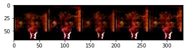

```python
# Best images generated by VGAN
import matplotlib.pyplot as plt
import matplotlib.image as mpimg

img = mpimg.imread('vgan_samples1.png')
plt.imshow(img)
plt.show()
```

Inceprion Score from one experimnet for the best Vanilla Generator results  
(1.6113879999240637, 0.34316588557051697)

In order to compare between Vanilla GAN, Spectral Normalization GAN and Wasserstein GAN we did the following:

Spectral Normalization GAN  
Spectral Normaliation was applied on all 2D convolution layer in Discriminator.(We used Pytorch Spectral Normalization implementation)

**Best Generator Results and Inception score of Spectral Normalization GAN**

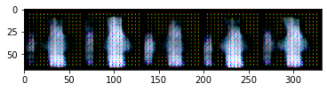

```python
# Best images generated by SNGAN
import matplotlib.pyplot as plt
import matplotlib.image as mpimg

img = mpimg.imread('sn_gan_samples1.png')
plt.imshow(img)
plt.show()
```

Inceprion Score from one experimnet for the best SNGenerator results  
(1.852318799572324, 0.25404013321981334)

Wasserstein GAN  
we implamented a specific training batch where the main changes are:

```
1. Discriminator loss function is D(x) - D(G(z))
<br>
2. Cliping Discriminator weights
<br>
3. Discriminator is trained more than the Generator, determined by n_critic
<br>
4. Generator loss function is D(G(z))
```

**Best Generator Results and Inception score of Wessarstein GAN**

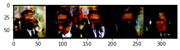

```python
# Best images generated by WGAN
import matplotlib.pyplot as plt
import matplotlib.image as mpimg

img = mpimg.imread('wgan_samples.png')
plt.imshow(img)
plt.show()
```

Inceprion Score from one experimnet for the best Wessarstein Generator results  
(5.10817613378421, 0.3873364827731096)

### Discussion

1. WE can see that applying Wesserstein approach on the Vanilla GAN, changing loss function to Earth Movers improved inception score and visually we can see the improvement in the face details and less blur in the picture
2. WE tried to implament Spectral Normalization according to the methods described in the attach paper about Spectral Normalization without any changes to hyperparameters and loss function in order to see if inception score and generated images improve. WE were not able to generate images close to our original images but inception score has improved a little in compare to vanilla GAN. We think that we were not able to generate images is releate to our Vanilla GAN architecture and the loss function of our Vanilla GAN.

NOTE:

All the corresponding code and notebooks for this task are placed inside the 'project' folder in the .zip archive. The checkpoints were not saved due to their large size, but the notebook "GAN_ver2.ipynb" is already executed.